# ANOVA, Multiple Comparisons, Post Hoc Tests

# The Problem with Multiple Comparisons

When doing multiple tests (aka multiple comparisons), our chances of making a Type I error increases.

*Type I error* is a “false positive” - we believe the means are different, but they actually are not different.

- Plan 1 vs plan 2: α = 5%
- Plan 1 vs plan 3: α = 5%
- Plan 2 vs. plan 3: α = 5%

The *family-wise error rate* formula is
$$1 - (1 - α)^C$$
where *alpha* is your significance level for a single test, and *C* is the number of tests.

$$1 - (1 - 0.05) ^ 3 =
0.142625$$

With family-wise α = 0.143, it’s much easier to find evidence of a difference in means!

In other words, there’s a 14% chance we’ll get a false positive (a Type I error)

This is why we use ANOVA to compare all the means all at once!

Null Hypothesis ($H_{0}$):

- $\mu_{1} = \mu_{2} = \mu_{3} = ... = \mu_{k}$

Alternative Hypothesis ($H_{a}$):

- The $\mu's$ are not all equal.
- At least one pair of means are different.

# Inputting our data

We need to tell R our weight loss data along with which group (treatment) each subject received.

```r
group <- c(1, 1, 1, 1, 2, 2, 2, 3, 3, 3)
group <- as.factor(group)

weightloss <- c(7, 9, 5, 7, 9, 11, 7, 15, 12, 18)
```

# Option 1 for ANOVA

```r
summary(aov(weightloss ~ group))
```

```
            Df Sum Sq Mean Sq F value  Pr(>F)
group        2    114   57.00   11.73 0.00581 **
Residuals    7     34    4.86
---
Signif. codes:  0 ‘***’ 0.001 ‘**’ 0.01 ‘*’ 0.05 ‘.’ 0.1 ‘ ’ 1
```

# Option 2 for ANOVA

```r
anova(lm(weightloss ~ group))
```

```
Analysis of Variance Table

Response: weightloss
          Df Sum Sq Mean Sq F value   Pr(>F)
group      2    114  57.000  11.735 0.005811 **
Residuals  7     34   4.857
---
Signif. codes:  0 ‘***’ 0.001 ‘**’ 0.01 ‘*’ 0.05 ‘.’ 0.1 ‘ ’ 1
```

# Calculate p-value for F-test

```r
pf(11.735,
   df1 = 2, #df(groups) or #df(numerator)
   df2 = 7, #df(error) or #df(denominator)
   lower.tail = FALSE
   )
```

```
[1] 0.005811518
```

```r
# 0.0058 * 100 = 0.58%
```

# Plot F distribution

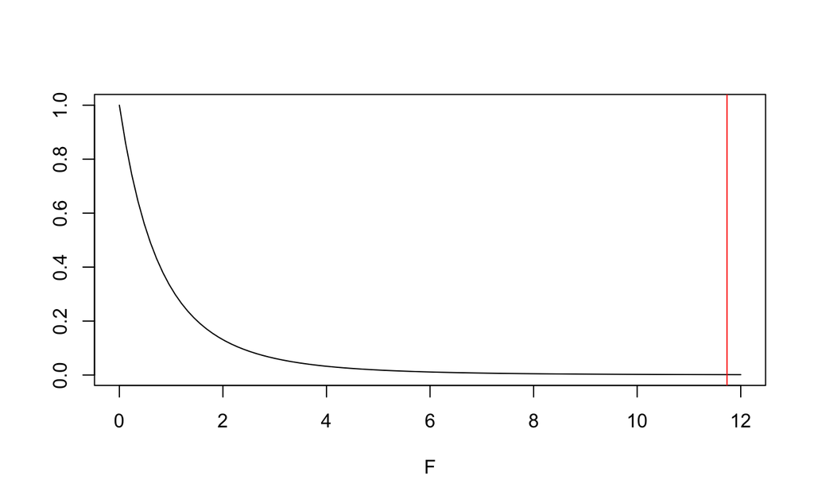

```r
# Plot an F distribution with 2 df in numerator and 7 df in denominator
# Use x-axis scale from 0 to 12
# "df" is not dataframe! It is a function that gives the "density of f distribution"
curve(df(x,
         df1=2,
         df2=7
         ),
      from=0,
      to=12,
      xlab = 'F',
      ylab = ''
)

# Put a red line at the F statistic
# The p-value is area under curve to the right of red line
abline(v = 11.735, col='red')
```

```r
# Recall critical F = 4.74
# 11.735 > 4.74 so we reject null
```

# Post Hoc Tests

If we find evidence that at least two of the group means are different, we’d like to know which pairs are different.

ANOVA tells us *if* there are differences among the means, but not which pair or pairs are significantly different. To find that out, we need to do a *Post-Hoc test*.

Post Hoc Tests

1. Bonferroni Correction
- adjust for multiple comparisons by making a more strict alpha level
- can be used for any test, not just ANOVA
2. Tukey’s Honestly Significant Difference (HSD) test
- do pairwise comparisons
- more powerful with large number of comparisons
- more common/preferred
3. Scheffe’s test
- See example [here](https://www.statisticshowto.com/scheffe-test/)
4. Fisher’s Least-Significant Difference (LSD) test
- See example [here](https://www.statisticshowto.com/how-to-calculate-the-least-significant-difference-lsd/)

For more details on post hoc tests, see [here](https://statisticsbyjim.com/anova/post-hoc-tests-anova/)

For a list of a bunch of post hoc tests, see [here](https://www.statisticshowto.com/probability-and-statistics/statistics-definitions/post-hoc/)

## Tukey’s HSD test

A common way to determine which pairs are really, honestly different is to use *Tukey’s HSD test*, HSD standing for “Honestly Significant Difference.”

### Run ANOVA and perform TukeyHSD

```r
# Fix our data frame so the Tukey test accepts it
### The order of the columns matters: response variable must be first!
resultsDF <- data.frame(weightloss, group)

# Store ANOVA results
resultsDFaov <- aov(lm(resultsDF))

# Perform test and store results so we can graph later
# TukeyHSD is in base R (no special package needed)
tukeytest <- TukeyHSD(resultsDFaov)

tukeytest
```

```
  Tukey multiple comparisons of means
    95% family-wise confidence level

Fit: aov(formula = lm(resultsDF))

$group
    diff        lwr       upr     p adj
2-1    2 -2.9572719  6.957272 0.4961594
3-1    8  3.0427281 12.957272 0.0051155
3-2    6  0.7004534 11.299547 0.0296150
```

```r
### The TukeyHSD uses an adjusted standard error formula unlike our typical two-sample t-interval
```

### Visualize Confidence Intervals from Tukey HSD

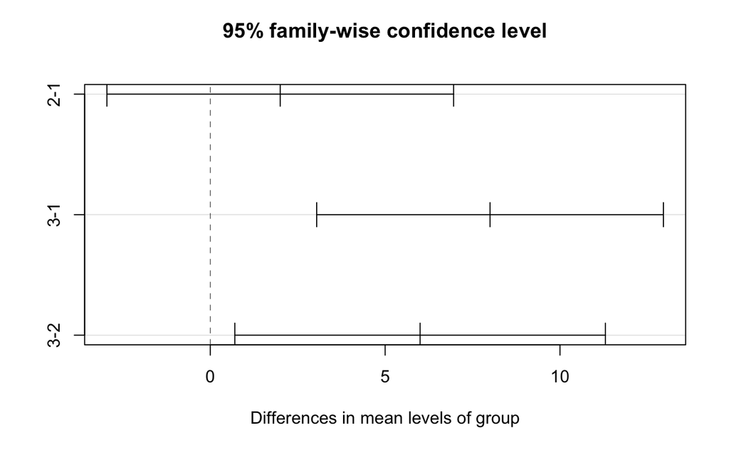

```r
plot(tukeytest)
```

For another TukeyHSD example, see [here](https://www.r-bloggers.com/2018/09/tukeys-test-for-post-hoc-analysis/)

## Bonferroni Correction

When doing multiple tests, our chances of type I error increase. How can we address this?

To find your adjusted significance level, divide the significance level (α) for a single test by the number of tests (n).

To calculate the number of tests, we use (k)(k-1) / 2, where k is the number of groups.

With three treatment groups, we have (3 * 2) / 2 = 3 tests

Note: With 4 groups we would have (4 * 3) / 2 = 6 tests (we would be comparing 1v2, 1v3, 1v4, 2v3, 2v4, 3v4)

Bonferroni correction = α / n

So, here we have an adjusted alpha level of 0.05 / 3 = 0.0167.

Now, in order to reject the null and find evidence that at least two means are different, the p-value from each separate two-sample t-test must be less than 0.0167.

For more info on Bonferroni, see [here](https://statisticsbyjim.com/hypothesis-testing/bonferroni-correction/)

## Multiple Two Sample T Tests and Bonferroni

```r
# Group weight loss by plan
plan1 <- c(7, 9, 5, 7)
plan2 <- c(9, 11, 7)
plan3 <- c(15, 12, 18)

# Run three t tests
t.test(plan1, plan2) #p = 0.23
t.test(plan1, plan3) #p = 0.03
t.test(plan2, plan3) #p = 0.053

### Defaults to t.test:
### var.equal = FALSE (Welch test)
### alternative = 'two.sided'

### For more info on t.test, see t.test documentation or https://www.statology.org/two-sample-t-test-in-r/
```

[output not shown]

We would fail to reject the null for all these tests using the Bonferroni correction (which is why it’s the most stringent test).

Sadly, our probability of Type II error increases (we get more false negatives), and the statistical power of our test decreases. We may miss out on the efficacy of the treatments.